# INN_Learner_Notebook_Full_code_version

## Model Performance Improvement

### Neural Network with Adam Optimizer

```python
backend.clear_session()
#Fixing the seed for random number generators so that we can ensure we receive the same output everytime
np.random.seed(2)
random.seed(2)
tf.random.set_seed(2)
```

```python
#Initializing the neural network
model_1 = Sequential()
# Adding the input layer with 64 neurons and relu as activation function
model_1.add(Dense(64, activation='relu', input_dim = X_train.shape[1]))
# Complete the code to add a hidden layer (specify the # of neurons and the activation function)
model_1.add(Dense(24, activation='relu'))
# Complete the code to add the output layer with the number of neurons required.
model_1.add(Dense(1, activation = 'sigmoid'))
```

```python
#Complete the code to use Adam as the optimizer.
optimizer = tf.keras.optimizers.Adam(learning_rate=0.001)

# uncomment one of the following lines to define the metric to be used
metric = 'accuracy'
metric = keras.metrics.Recall()
# metric = keras.metrics.Precision()
# metric = keras.metrics.F1Score()
```

```python
# Create optimizer with default learning rate
# Compile the model
model_0.compile(optimizer='adam',loss='binary_crossentropy',metrics=[metric])
```

```python
model_0.summary()
```

```
Model: "sequential"
_________________________________________________________________
 Layer (type)                Output Shape              Param #
=================================================================
 dense (Dense)               (None, 64)                768

 dense_1 (Dense)             (None, 24)                1560

 dense_2 (Dense)             (None, 1)                 25

=================================================================
Total params: 2353 (9.19 KB)
Trainable params: 2353 (9.19 KB)
Non-trainable params: 0 (0.00 Byte)
_________________________________________________________________
```

```python
# Fitting the ANN

# Cast X_train and y_train to float32
X_train = X_train.astype('float32')
y_train = y_train.astype('float32')

# Specify the batch size and epochs
batch_size = 15
epochs = 10

history_1 = model_0.fit(
    X_train, y_train,
    batch_size=batch_size,    ## Complete the code to specify the batch size to use
    validation_data=(X_val,y_val),
    epochs=epochs,    ## Complete the code to specify the number of epochs
    verbose=1
)
```

**Loss function**

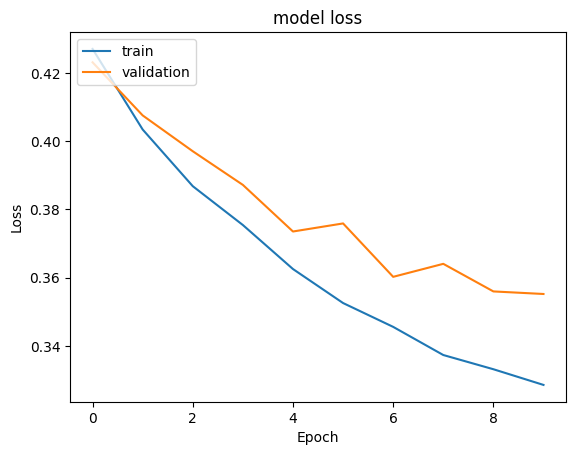

```python
#Plotting Train Loss vs Validation Loss
plt.plot(history_1.history['loss'])
plt.plot(history_1.history['val_loss'])
plt.title('model loss')
plt.ylabel('Loss')
plt.xlabel('Epoch')
plt.legend(['train', 'validation'], loc='upper left')
plt.show()
```

**Recall**

```python
print(history_1.history.keys())
```

```
dict_keys(['loss', 'recall', 'val_loss', 'val_recall'])
```

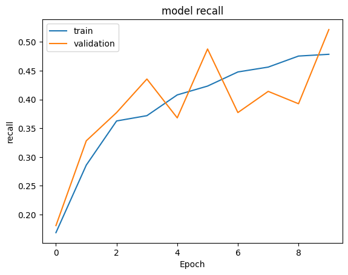

```python
#Plotting Train recall vs Validation recall
plt.plot(history_1.history['recall'])
plt.plot(history_1.history['val_recall'])
plt.title('model recall')
plt.ylabel('recall')
plt.xlabel('Epoch')
plt.legend(['train', 'validation'], loc='upper left')
plt.show()
```

```python
#Predicting the results using 0.5 as the threshold
y_train_pred = model_1.predict(X_train)
y_train_pred = (y_train_pred > 0.5)
y_train_pred
```

```
array([[False],
       [ True],
       [ True],
       ...,
       [ True],
       [ True],
       [ True]])
```

```python
#Predicting the results using 0.5 as the threshold
y_val_pred = model_1.predict(X_val)
y_val_pred = (y_val_pred > 0.5)
y_val_pred
```

```
array([[False],
       [ True],
       [False],
       ...,
       [False],
       [ True],
       [ True]])
```

```python
model_name = "NN with Adam"

train_metric_df.loc[model_name] = recall_score(y_train,y_train_pred)
valid_metric_df.loc[model_name] = recall_score(y_val,y_val_pred)
```

**Classification report**

```python
#lassification report
cr=classification_report(y_train,y_train_pred)
print(cr)
```

```
              precision    recall  f1-score   support

         0.0       0.80      0.15      0.25      5096
         1.0       0.20      0.86      0.33      1304

    accuracy                           0.29      6400
   macro avg       0.50      0.50      0.29      6400
weighted avg       0.68      0.29      0.26      6400
```

```python
#classification report
cr=classification_report(y_val,y_val_pred)  ## Complete the code to check the model's performance on the validation set
print(cr)
```

```
              precision    recall  f1-score   support

           0       0.85      0.14      0.24      1274
           1       0.21      0.90      0.34       326

    accuracy                           0.29      1600
   macro avg       0.53      0.52      0.29      1600
weighted avg       0.72      0.29      0.26      1600
```

**Confusion matrix**

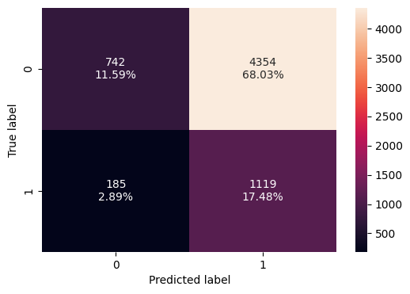

```python
#Calculating the confusion matrix
make_confusion_matrix(y_train, y_train_pred)
```

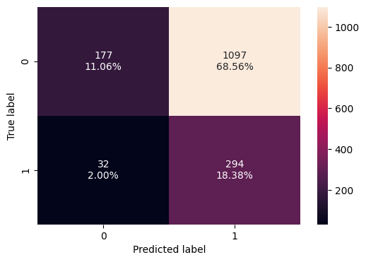

```python
#Calculating the confusion matrix
make_confusion_matrix(y_val,y_val_pred)  ## Complete the code to check the model's performance on the validation set
```

### Neural Network with Adam Optimizer and Dropout

```python
backend.clear_session()
#Fixing the seed for random number generators so that we can ensure we receive the same output everytime
np.random.seed(2)
random.seed(2)
tf.random.set_seed(2)
```

```python
#Initializing the neural network
model_2 = Sequential()

#Adding the input layer with 32 neurons and relu as activation function
model_2.add(Dense(32, activation='relu', input_dim=X_train.shape[1]))

# Adding dropout with ratio of 0.2
model_2.add(Dropout(0.2))

# Adding a hidden layer with 64 neurons and relu as activation function
model_2.add(Dense(64, activation='relu'))

# Adding a hidden layer with 64 neurons and relu as activation function
model_2.add(Dense(64, activation='relu'))

# Adding dropout with ratio of 0.1
model_2.add(Dropout(0.1))

# Adding a hidden layer with 32 neurons and relu as activation function
model_2.add(Dense(32, activation='relu'))

# Adding the output layer with the appropriate number of neurons and activation function
model_2.add(Dense(1, activation='sigmoid'))
```

```python
#Complete the code to use Adam as the optimizer.
optimizer = tf.keras.optimizers.Adam(learning_rate=0.001)

# uncomment one of the following lines to define the metric to be used
metric = 'accuracy'
metric = keras.metrics.Recall()
# metric = keras.metrics.Precision()
# metric = keras.metrics.F1Score()
```

```python
## Complete the code to compile the model with binary cross entropy as loss function and recall as the metric.
model_2.compile(loss='loss',optimizer=optimizer,metrics=[metric])
```

```python
# Summary of the model
model_2.summary()
```

```
Model: "sequential"
_________________________________________________________________
 Layer (type)                Output Shape              Param #
=================================================================
 dense (Dense)               (None, 32)                384

 dropout (Dropout)           (None, 32)                0

 dense_1 (Dense)             (None, 64)                2112

 dense_2 (Dense)             (None, 64)                4160

 dropout_1 (Dropout)         (None, 64)                0

 dense_3 (Dense)             (None, 32)                2080

 dense_4 (Dense)             (None, 1)                 33

=================================================================
Total params: 8769 (34.25 KB)
Trainable params: 8769 (34.25 KB)
Non-trainable params: 0 (0.00 Byte)
_________________________________________________________________
```

```python
# Fitting the ANN

# Cast X_train and y_train to float32
X_train = X_train.astype('float32')
y_train = y_train.astype('float32')

# Specify the batch size and epochs
batch_size = 15
epochs = 10

history_2 = model_0.fit(
    X_train, y_train,
    batch_size=batch_size,    ## Code to specify the batch size to use
    validation_data=(X_val,y_val),
    epochs=epochs,    ## Code to specify the number of epochs
    verbose=1

)
```

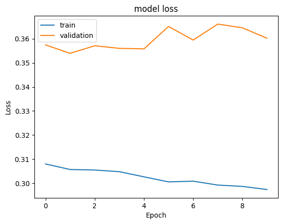

```python
#Plotting Train Loss vs Validation Loss
plt.plot(history_2.history['loss'])
plt.plot(history_2.history['val_loss'])
plt.title('model loss')
plt.ylabel('Loss')
plt.xlabel('Epoch')
plt.legend(['train', 'validation'], loc='upper left')
plt.show()
```

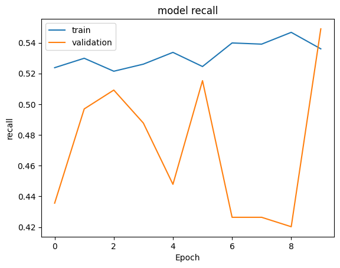

```python
#Plotting Train recall vs Validation recall
plt.plot(history_2.history['recall'])
plt.plot(history_2.history['val_recall'])
plt.title('model recall')
plt.ylabel('recall')
plt.xlabel('Epoch')
plt.legend(['train', 'validation'], loc='upper left')
plt.show()
```

```python
#Predicting the results using best as a threshold
y_train_pred = model_2.predict(X_train)
y_train_pred = (y_train_pred > 0.5)
y_train_pred
```

```
array([[False],
       [False],
       [False],
       ...,
       [ True],
       [ True],
       [False]])
```

```python
#Predicting the results using 0.5 as the threshold.
y_val_pred = model_2.predict(X_val)
y_val_pred = (y_val_pred > 0.5)
y_val_pred
```

```
array([[ True],
       [ True],
       [ True],
       ...,
       [ True],
       [ True],
       [False]])
```

```python
model_name = "NN with Adam & Dropout"

train_metric_df.loc[model_name] = recall_score(y_train,y_train_pred)
valid_metric_df.loc[model_name] = recall_score(y_val,y_val_pred)
```

**Classification report**

```python
#classification report
cr=classification_report(y_train,y_train_pred)
print(cr)
```

```
              precision    recall  f1-score   support

         0.0       0.83      0.56      0.67      5096
         1.0       0.24      0.55      0.33      1304

    accuracy                           0.56      6400
   macro avg       0.53      0.55      0.50      6400
weighted avg       0.71      0.56      0.60      6400
```

```python
#classification report
cr = classification_report(y_val,y_val_pred) ## Complete the code to check the model's performance on the validation set
print(cr)
```

```
              precision    recall  f1-score   support

           0       0.83      0.57      0.68      1274
           1       0.24      0.54      0.33       326

    accuracy                           0.56      1600
   macro avg       0.54      0.55      0.51      1600
weighted avg       0.71      0.56      0.61      1600
```

**Confusion matrix**

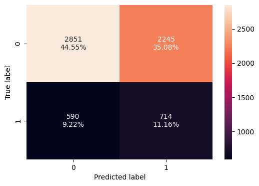

```python
#Calculating the confusion matrix
make_confusion_matrix(y_train, y_train_pred)
```

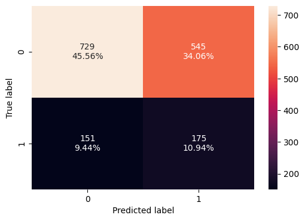

```python
#Calculating the confusion matrix
make_confusion_matrix(y_val,y_val_pred)  ## Complete the code to check the model's performance on the validation set
```

```python
sm  = SMOTE(random_state=42)
#Complete the code to fit SMOTE on the training data.
X_train_smote, y_train_smote= sm.fit_resample(X_train, y_train)
print('After UpSampling, the shape of train_X: {}'.format(X_train_smote.shape))
print('After UpSampling, the shape of train_y: {} \n'.format(y_train_smote.shape))
```

```
After UpSampling, the shape of train_X: (10192, 11)
After UpSampling, the shape of train_y: (10192,)
```

```python
backend.clear_session()
#Fixing the seed for random number generators so that we can ensure we receive the same output everytime
np.random.seed(2)
random.seed(2)
tf.random.set_seed(2)
```

```python
# Initializing the model
model_3 = Sequential()

# Adding the input layer with appropriate number of neurons and activation function
model_3.add(Dense(32, activation='relu', input_dim=X_train_smote.shape[1]))

# Adding a hidden layer with 16 neurons and activation function (you can adjust the number of neurons as needed)
model_3.add(Dense(16, activation='relu'))

# Adding another hidden layer with appropriate number of neurons and activation function
model_3.add(Dense(16, activation='relu'))

# Adding the output layer with 1 neuron and sigmoid activation function for binary classification
model_3.add(Dense(1, activation='sigmoid'))
```

```python
#Code to use Adam as the optimizer.
optimizer = tf.keras.optimizers.SGD(learning_rate=0.001)

# uncomment one of the following lines to define the metric to be used
metric = 'accuracy'
metric = keras.metrics.Recall()
# metric = keras.metrics.Precision()
# metric = keras.metrics.F1Score()
```

```python
# Code to compile the model with binary cross entropy as loss function and recall as the metric
model_3.compile(loss='binary_crossentropy',optimizer=optimizer,metrics=[metric])
```

```python
model_3.summary()
```

```
Model: "sequential"
_________________________________________________________________
 Layer (type)                Output Shape              Param #
=================================================================
 dense (Dense)               (None, 32)                384

 dense_1 (Dense)             (None, 16)                528

 dense_2 (Dense)             (None, 16)                272

 dense_3 (Dense)             (None, 1)                 17

=================================================================
Total params: 1201 (4.69 KB)
Trainable params: 1201 (4.69 KB)
Non-trainable params: 0 (0.00 Byte)
_________________________________________________________________
```

```python
# Fitting the ANN

# Cast X_train and y_train to float32
X_train = X_train.astype('float32')
y_train = y_train.astype('float32')



history_3 = model_3.fit(
    X_train, y_train,
    batch_size=32,    ## Complete the code to specify the batch size to use
    validation_data=(X_val,y_val),
    epochs=50,    ## Complete the code to specify the number of epochs
    verbose=1
 )
```

```python
print(history_3.history.keys())
```

```
dict_keys(['loss', 'recall_1', 'val_loss', 'val_recall_1'])
```

**Loss function**

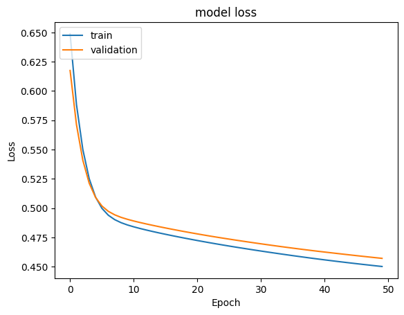

```python
#Plotting Train Loss vs Validation Loss
plt.plot(history_3.history['loss'])
plt.plot(history_3.history['val_loss'])
plt.title('model loss')
plt.ylabel('Loss')
plt.xlabel('Epoch')
plt.legend(['train', 'validation'], loc='upper left')
plt.show()
```

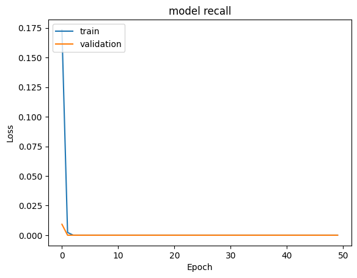

```python
#Plotting Train recall vs Validation recall
plt.plot(history_3.history['recall_1'])
plt.plot(history_3.history['val_recall_1'])
plt.title('model recall')
plt.ylabel('Loss')
plt.xlabel('Epoch')
plt.legend(['train', 'validation'], loc='upper left')
plt.show()
```

```python
y_train_pred = model_3.predict(X_train_smote)
#Predicting the results using 0.5 as the threshold
y_train_pred = (y_train_pred > 0.5)
y_train_pred
```

```
array([[False],
       [False],
       [False],
       ...,
       [False],
       [False],
       [False]])
```

```python
y_val_pred = model_3.predict(X_val)
#Predicting the results using 0.5 as the threshold
y_val_pred = (y_val_pred > 0.5)
y_val_pred
```

```
array([[False],
       [False],
       [False],
       ...,
       [False],
       [False],
       [False]])
```

```python
model_name = "NN with SMOTE & SGD"

train_metric_df.loc[model_name] = recall_score(y_train_smote,y_train_pred)
valid_metric_df.loc[model_name] = recall_score(y_val,y_val_pred)
```

**Classification report**

```python
cr=classification_report(y_train_smote,y_train_pred)
print(cr)
```

```
              precision    recall  f1-score   support

         0.0       0.50      1.00      0.67      5096
         1.0       0.00      0.00      0.00      5096

    accuracy                           0.50     10192
   macro avg       0.25      0.50      0.33     10192
weighted avg       0.25      0.50      0.33     10192
```

```python
cr=classification_report(y_val,y_val_pred) ## Complete the code to check the model's performance on the validation set
print(cr)
```

```
              precision    recall  f1-score   support

           0       0.80      1.00      0.89      1274
           1       0.00      0.00      0.00       326

    accuracy                           0.80      1600
   macro avg       0.40      0.50      0.44      1600
weighted avg       0.63      0.80      0.71      1600
```

**Confusion matrix**

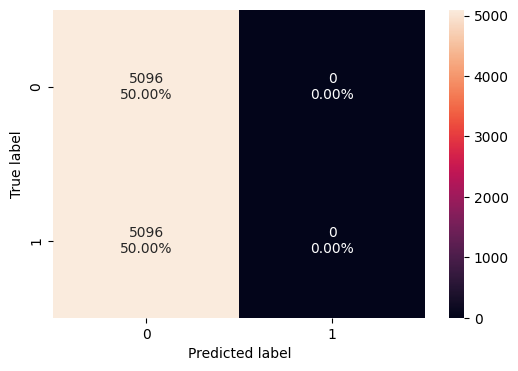

```python
#Calculating the confusion matrix
make_confusion_matrix(y_train_smote, y_train_pred)
```

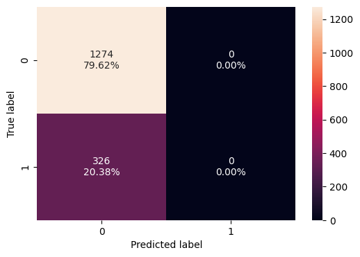

```python
#Calculating the confusion matrix

make_confusion_matrix(y_val,y_val_pred) ## Complete the code to check the model's performance on the validation set
```

### Neural Network with Balanced Data (by applying SMOTE) and Adam Optimizer

```python
backend.clear_session()
#Fixing the seed for random number generators so that we can ensure we receive the same output everytime
np.random.seed(2)
random.seed(2)
tf.random.set_seed(2)
```

```python
# Initializing the model
model_4 = Sequential()

# Adding the input layer with appropriate number of neurons and activation function
model_4.add(Dense(64, activation='relu', input_dim=X_train_smote.shape[1]))

# Adding a hidden layer with 32 neurons and activation function (you can adjust the number of neurons as needed)
model_4.add(Dense(32, activation='relu'))

# Adding another hidden layer with 16 neurons and activation function
model_4.add(Dense(16, activation='relu'))

# Adding the output layer with 1 neuron and sigmoid activation function for binary classification
model_4.add(Dense(1, activation='sigmoid'))
```

```python
model_4.summary()
```

```
Model: "sequential"
_________________________________________________________________
 Layer (type)                Output Shape              Param #
=================================================================
 dense (Dense)               (None, 64)                768

 dense_1 (Dense)             (None, 32)                2080

 dense_2 (Dense)             (None, 16)                528

 dense_3 (Dense)             (None, 1)                 17

=================================================================
Total params: 3393 (13.25 KB)
Trainable params: 3393 (13.25 KB)
Non-trainable params: 0 (0.00 Byte)
_________________________________________________________________
```

```python
#Complete the code to use Adam as the optimizer.
optimizer = tf.keras.optimizers.Adam(learning_rate=0.001)

# uncomment one of the following lines to define the metric to be used
metric = 'accuracy'
metric = keras.metrics.Recall()
# metric = keras.metrics.Precision()
# metric = keras.metrics.F1Score()
```

```python
# Complete the code to compile the model with binary cross entropy as loss function and recall as the metric
model_4.compile(loss='binary_crossentropy',optimizer=optimizer,metrics=[metric])
```

```python
model_4.summary()
```

```
Model: "sequential"
_________________________________________________________________
 Layer (type)                Output Shape              Param #
=================================================================
 dense (Dense)               (None, 64)                768

 dense_1 (Dense)             (None, 32)                2080

 dense_2 (Dense)             (None, 16)                528

 dense_3 (Dense)             (None, 1)                 17

=================================================================
Total params: 3393 (13.25 KB)
Trainable params: 3393 (13.25 KB)
Non-trainable params: 0 (0.00 Byte)
_________________________________________________________________
```

```python
#Fitting the ANN

history_4 = model_4.fit(
    X_train_smote, y_train_smote,
    batch_size=32,    ## Code to specify the batch size to use (you can adjust as per your preference)
    epochs=50,  ## Code to specify the number of epochs (you can adjust as per your preference)
    verbose=1,
    validation_data=(X_val, y_val)
)
```

**Loss function**

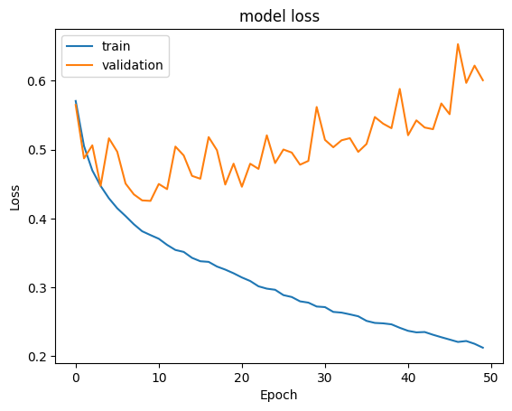

```python
#Plotting Train Loss vs Validation Loss
plt.plot(history_4.history['loss'])
plt.plot(history_4.history['val_loss'])
plt.title('model loss')
plt.ylabel('Loss')
plt.xlabel('Epoch')
plt.legend(['train', 'validation'], loc='upper left')
plt.show()
```

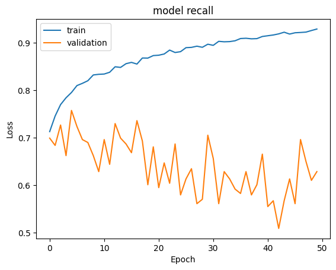

```python
#Plotting Train recall vs Validation recall
plt.plot(history_4.history['recall'])
plt.plot(history_4.history['val_recall'])
plt.title('model recall')
plt.ylabel('Loss')
plt.xlabel('Epoch')
plt.legend(['train', 'validation'], loc='upper left')
plt.show()
```

```python
y_train_pred = model_4.predict(X_train_smote)
#Predicting the results using 0.5 as the threshold
y_train_pred = (y_train_pred > 0.5)
y_train_pred
```

```
array([[ True],
       [False],
       [False],
       ...,
       [ True],
       [ True],
       [ True]])
```

```python
y_val_pred = model_4.predict(X_val)
#Predicting the results using 0.5 as the threshold
y_val_pred = (y_val_pred > 0.5)
y_val_pred
```

```
array([[False],
       [False],
       [False],
       ...,
       [False],
       [ True],
       [ True]])
```

```python
model_name = "NN with SMOTE & Adam"

train_metric_df.loc[model_name] = recall_score(y_train_smote,y_train_pred)
valid_metric_df.loc[model_name] = recall_score(y_val,y_val_pred)
```

```python
cr=classification_report(y_train_smote,y_train_pred)
print(cr)
```

```
              precision    recall  f1-score   support

         0.0       0.96      0.89      0.92      5096
         1.0       0.90      0.96      0.93      5096

    accuracy                           0.92     10192
   macro avg       0.93      0.92      0.92     10192
weighted avg       0.93      0.92      0.92     10192
```

```python
cr=classification_report(y_val,y_val_pred) ## Complete the code to check the model's performance on the validation set
print(cr)
```

```
              precision    recall  f1-score   support

           0       0.90      0.82      0.86      1274
           1       0.47      0.63      0.54       326

    accuracy                           0.78      1600
   macro avg       0.68      0.72      0.70      1600
weighted avg       0.81      0.78      0.79      1600
```

**Confusion matrix**

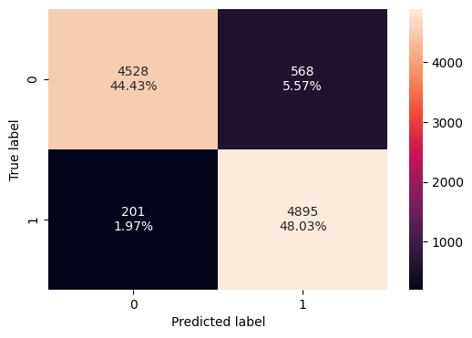

```python
#Calculating the confusion matrix
make_confusion_matrix(y_train_smote, y_train_pred)
```

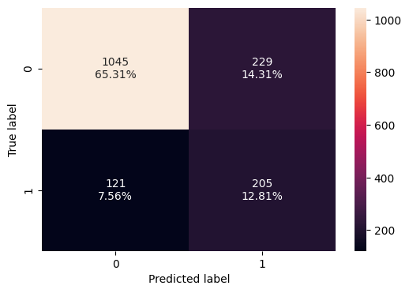

```python
#Calculating the confusion matrix
make_confusion_matrix(y_val,y_val_pred)  ## Complete the code to check the model's performance on the validation set
```

### Neural Network with Balanced Data (by applying SMOTE), Adam Optimizer, and Dropout

```python
backend.clear_session()
#Fixing the seed for random number generators so that we can ensure we receive the same output everytime
np.random.seed(2)
random.seed(2)
tf.random.set_seed(2)
```

```python
from tensorflow.keras.layers import Dropout

# Initializing the model
model_5 = Sequential()

# Adding the input layer with appropriate number of neurons and activation function (you need to specify the number of neurons)
model_5.add(Dense(64, activation='relu', input_dim=X_train_smote.shape[1]))

# Adding dropout layer with a dropout rate (you need to specify the dropout rate)
model_5.add(Dropout(0.2))

# Adding a hidden layer with appropriate number of neurons and activation function (you need to specify the number of neurons and activation function)
model_5.add(Dense(32, activation='relu'))

# Adding dropout layer with a dropout rate (you need to specify the dropout rate)
model_5.add(Dropout(0.2))

# Adding another hidden layer with 8 neurons and relu activation function
model_5.add(Dense(8, activation='relu'))

# Adding the output layer with the appropriate number of neurons and activation function (you need to specify the number of neurons and activation function)
model_5.add(Dense(1, activation='sigmoid'))
```

```python
#Complete the code to use Adam as the optimizer.
optimizer = tf.keras.optimizers.Adam(learning_rate=0.001)

# uncomment one of the following lines to define the metric to be used
metric = 'accuracy'
metric = keras.metrics.Recall()
# metric = keras.metrics.Precision()
# metric = keras.metrics.F1Score()
```

```python
# Complete the code to compile the model with binary cross entropy as loss function and recall as the metric
model_5.compile(loss='binary_crossentropy',optimizer=optimizer,metrics=[metric])
```

```python
model_5.summary()
```

```
Model: "sequential"
_________________________________________________________________
 Layer (type)                Output Shape              Param #
=================================================================
 dense (Dense)               (None, 64)                768

 dropout (Dropout)           (None, 64)                0

 dense_1 (Dense)             (None, 32)                2080

 dropout_1 (Dropout)         (None, 32)                0

 dense_2 (Dense)             (None, 8)                 264

 dense_3 (Dense)             (None, 1)                 9

=================================================================
Total params: 3121 (12.19 KB)
Trainable params: 3121 (12.19 KB)
Non-trainable params: 0 (0.00 Byte)
_________________________________________________________________
```

```python
history_5 = model_5.fit(
    X_train_smote,y_train_smote,
    batch_size=32, ## Code to specify the batch size to use
    epochs=50, ## Code to specify the number of epochs
    verbose=1,
    validation_data = (X_val,y_val))
```

**Loss function**

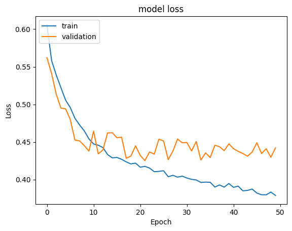

```python
#Plotting Train Loss vs Validation Loss
plt.plot(history_5.history['loss'])
plt.plot(history_5.history['val_loss'])
plt.title('model loss')
plt.ylabel('Loss')
plt.xlabel('Epoch')
plt.legend(['train', 'validation'], loc='upper left')
plt.show()
```

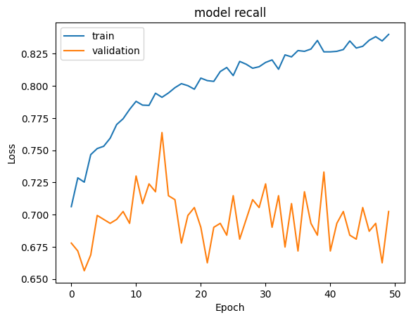

```python
#Plotting Train recall vs Validation recall
plt.plot(history_5.history['recall'])
plt.plot(history_5.history['val_recall'])
plt.title('model recall')
plt.ylabel('Loss')
plt.xlabel('Epoch')
plt.legend(['train', 'validation'], loc='upper left')
plt.show()
```

```python
y_train_pred = model_5.predict(X_train_smote)
#Predicting the results using 0.5 as the threshold
y_train_pred = (y_train_pred > 0.5)
y_train_pred
```

```
array([[ True],
       [False],
       [False],
       ...,
       [ True],
       [ True],
       [ True]])
```

```python
y_val_pred = model_5.predict(X_val)
#Predicting the results using 0.5 as the threshold
y_val_pred = (y_val_pred > 0.5)
y_val_pred
```

```
array([[False],
       [False],
       [False],
       ...,
       [False],
       [ True],
       [ True]])
```

```python
model_name = "NN with SMOTE,Adam & Dropout"

train_metric_df.loc[model_name] = recall_score(y_train_smote,y_train_pred)
valid_metric_df.loc[model_name] = recall_score(y_val,y_val_pred)
```

**Classification report**

```python
cr=classification_report(y_train_smote,y_train_pred)
print(cr)
```

```
              precision    recall  f1-score   support

         0.0       0.86      0.85      0.86      5096
         1.0       0.85      0.86      0.86      5096

    accuracy                           0.86     10192
   macro avg       0.86      0.86      0.86     10192
weighted avg       0.86      0.86      0.86     10192
```

```python
#classification report
cr=classification_report(y_val,y_val_pred)  ## Complete the code to check the model's performance on the validation set
print(cr)
```

```
              precision    recall  f1-score   support

           0       0.92      0.84      0.87      1274
           1       0.52      0.70      0.60       326

    accuracy                           0.81      1600
   macro avg       0.72      0.77      0.74      1600
weighted avg       0.84      0.81      0.82      1600
```

**Confusion matrix**

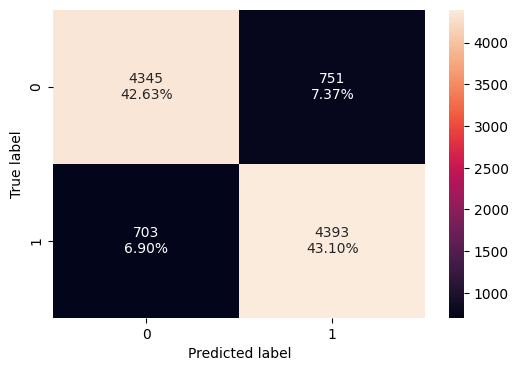

```python
#Calculating the confusion matrix
make_confusion_matrix(y_train_smote, y_train_pred)
```

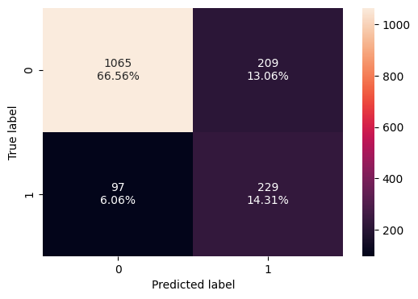

```python
#Calculating the confusion matrix
make_confusion_matrix(y_val,y_val_pred)  ## Complete the code to check the model's performance on the validation set
```

## Model Performance Comparison and Final Model Selection

```python
print("Training performance comparison")
train_metric_df
```

```
Training performance comparison
```

|  | recall |
| --- | --- |
| NN with SGD | 0.007669 |
| NN with Adam | 0.858129 |
| NN with Adam & Dropout | 0.547546 |
| NN with SMOTE & SGD | 0.000000 |
| NN with SMOTE & Adam | 0.960557 |
| NN with SMOTE,Adam & Dropout | 0.862049 |

```python
print("Validation set performance comparison")
valid_metric_df
```

```
Validation set performance comparison
```

|  | recall |
| --- | --- |
| NN with SGD | 0.006135 |
| NN with Adam | 0.901840 |
| NN with Adam & Dropout | 0.536810 |
| NN with SMOTE & SGD | 0.000000 |
| NN with SMOTE & Adam | 0.628834 |
| NN with SMOTE,Adam & Dropout | 0.702454 |

```python
train_metric_df - valid_metric_df
```

|  | recall |
| --- | --- |
| NN with SGD | 0.001534 |
| NN with Adam | -0.043712 |
| NN with Adam & Dropout | 0.010736 |
| NN with SMOTE & SGD | 0.000000 |
| NN with SMOTE & Adam | 0.331723 |
| NN with SMOTE,Adam & Dropout | 0.159595 |

```python
y_test_pred = model_2.predict(X_test)    ## Complete the code to specify the best model
y_test_pred = (y_test_pred > 0.5)
print(y_test_pred)
```

```
[[False]
 [ True]
 [False]
 ...
 [ True]
 [ True]
 [False]]
```

```python
#lets print classification report
cr=classification_report(y_test,y_test_pred)
print(cr)
```

```
              precision    recall  f1-score   support

           0       0.83      0.56      0.67      1593
           1       0.24      0.54      0.33       407

    accuracy                           0.56      2000
   macro avg       0.53      0.55      0.50      2000
weighted avg       0.71      0.56      0.60      2000
```

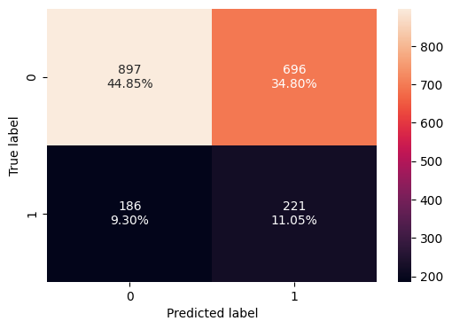

```python
#Calculating the confusion matrix
make_confusion_matrix(y_test,y_test_pred)
```

## Actionable Insights and Business Recommendations

From that model, it is obvoius that:

**Bussiness Insights**

• The Churn data shows a complete imbalance of "Exited" options. There are 79.63% 'Not Exited' (0) instances and only 20.37% 'Exited' (1) instances. This means that we are aiming to predict anomalous events.

• Although dataset is imbalanced, stil the customers who are having credit score less than 700 have more chances of leaving the bank and chance of leaving the bank reduces gradually after 700.

• Customers who are staying in the bank and having high credit score are in less population when compared to other categories of credit scores, we can derive to more conclusions that they may not like the outcomes of the bank or have found a better bank to have an account with more benefits.

• Chances of Leaving the Bank is more up to 45 Years after that it is more or less equal either staying or leaving the bannk among the ages 50-60 age groups.

• The data seems to be left skewed and customers having balance between 50K and 175K tend to churn more.

• Around 200-250 customers are leaving the bank and this scenario is even across all Salaries. So, no correlation between Exited vs Estimated Salary.

• Around 50 % are France customers and Germany and Spain are 25% more or less equal. Male customers are 54.57 %. Male customers are 45.43 %

• German & France customers together having more churned customers (800+) than Spain (400+).

• Female Customers are more churning than male customers.

• Both Customers with or without credit cards are equally leaving the bank.

• More active members are leaving the bank then non-active members.

• Customers belong to approx. 600 - 700 credit score, leaving the bank.

• Customers between 40-50 years churning.

• Customers between 2-8 years tenure tend to churn.

• Customers with <=2 products churning.

```python
%%shell
jupyter nbconvert --to html ///content/INN_Learner_Notebook_Full_code_version-2.ipynb
```

```
[NbConvertApp] Converting notebook ///content/INN_Learner_Notebook_Full_code_version-2.ipynb to html
[NbConvertApp] Writing 1286722 bytes to /content/INN_Learner_Notebook_Full_code_version-2.html
```